# Univariate Forecasts

In this part we evaluate univariate forecasts of the gas consumption.

## Graphical Analysis and stationarity

### Load useful packages & data

```r
library(readr)
library(forecast)
library(ggplot2)
library(knitr)
gas <- na.omit(read_csv("data/gas.csv", col_types = cols(date = col_date(format = "%Y-%m-%d"))))
```

We also define functions for the RMS error which we will use as the main evaluation metric here.

```r
direct_rmse <- function(l, r) {sqrt(sum((l - r)^2)/NROW(l))}
exp_rmse <- function(l, r) {direct_rmse(exp(l), exp(r))}
```

### Stationarity and integration of the consumption

Let us plot the values, ACF and PACF of the data and its logarithm, with seasonal and annual differentiation.

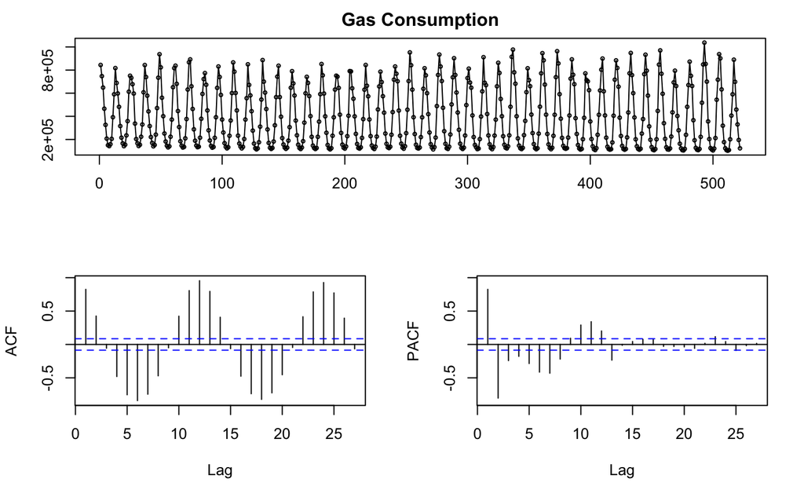

```r
tsdisplay(gas$gas_cons,main="Gas Consumption")
```

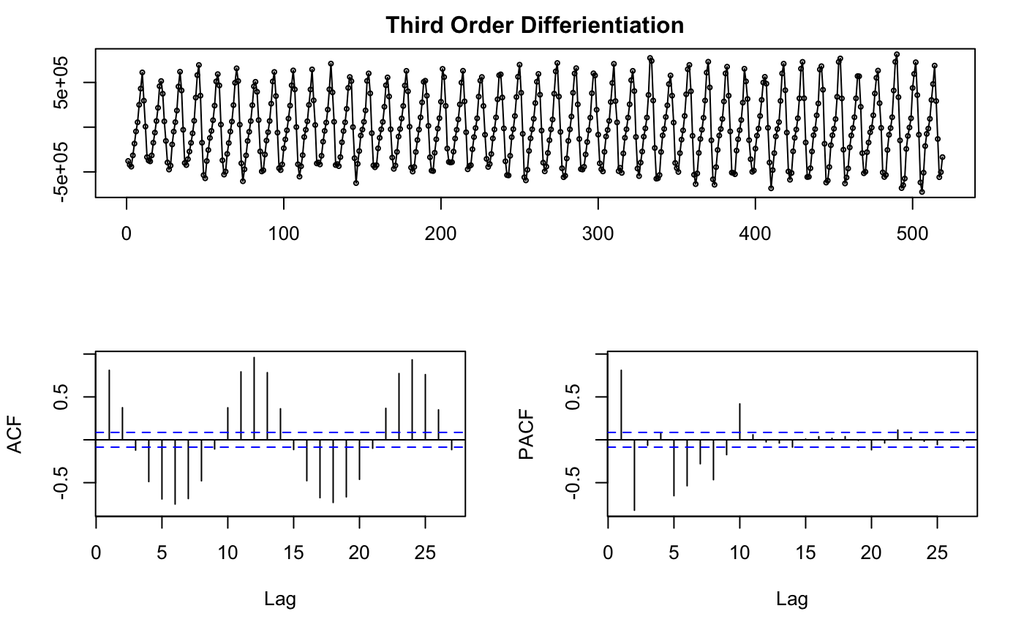

```r
tsdisplay(diff(gas$gas_cons, 3), main="Third Order Differientiation")
```

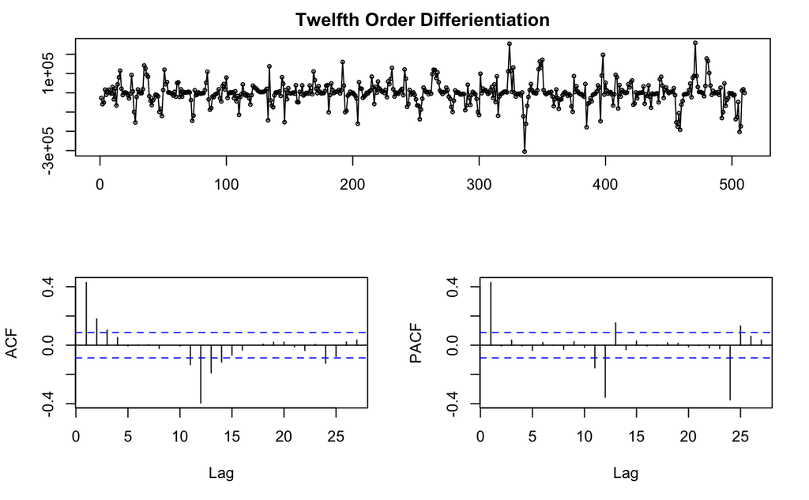

```r
tsdisplay(diff(gas$gas_cons, 12), main="Twelfth Order Differientiation")
```

The results are similar to that of the log of the consumption. Annual differencing seem to yield a somewhat stationary process with no obvious seasonality.

### Stationarity and integration of the log of the consumption

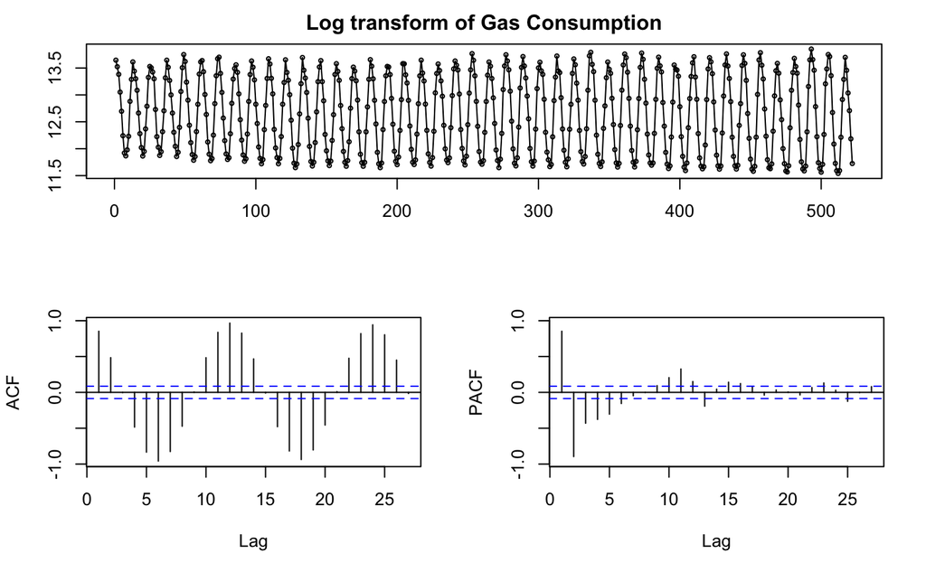

```r
tsdisplay(gas$log_gas_cons,main="Log transform of Gas Consumption")
```

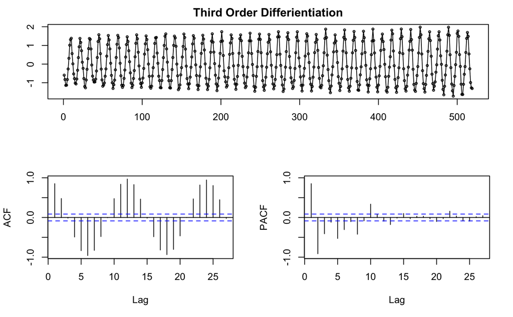

```r
tsdisplay(diff(gas$log_gas_cons, 3), main="Third Order Differientiation")
```

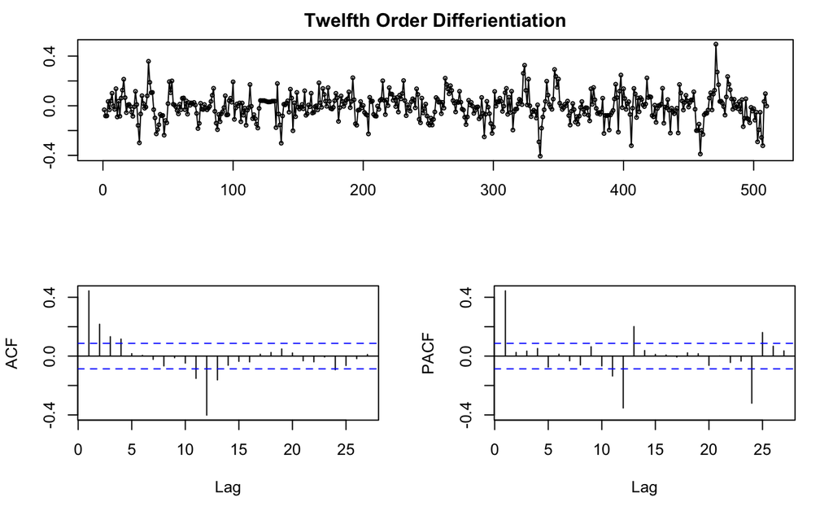

```r
tsdisplay(diff(gas$log_gas_cons, 12), main="Twelfth Order Differientiation")
```

Unsurprisingly, the results are globally similar: we notice a strong seasonality, still observable after seasonal differencing. Exploring further the dynamics of the log consumption with annual differencing yields a time series that looks stationary.

Let us perform statistical tests on the log gas consumption for stationarity with differencing and seasonal differencing:

```r
ndiffs(gas$log_gas_cons, alpha=0.05, test=c("kpss","adf", "pp"), max.d=2)
```

```
[1] 0
```

```r
nsdiffs(gas$log_gas_cons, m=12, test=c("ocsb","ch"), max.D=1)
```

```
[1] 1
```

The unit root test with level 0.05 indicates there is no need for differencing to obtain a stationary time series, but here the strong seasonality makes it irrelevant. We thus look at seasonal differencing which shows there is a need for first order seasonal differencing for the series to become stationary.

### Pre-processing

Let us convert data into time series and split it into a training set and a one year test set to evaluate our first models.

```r
lgas = ts(gas$log_gas_cons, start = c(1973, 1), frequency=12)
train = window(lgas, start = c(1973, 1), end = c(2015, 6))
test = window(lgas, start = c(2015,7), end = c(2016, 6))
dgas = ts(gas$gas_cons, start = c(1973, 1), frequency=12)
dtrain = window(dgas, start = c(1973, 1), end = c(2015, 6))
dtest = window(dgas, start = c(2015, 7), end = c(2016, 6))
```

## Time Series Decomposition with log gas consumption

Let’s try to decompose our series in three components: trend, seasonality and error. We assume seasonality is fixed across years and we do our analysis on the log of consumption data to avoid overweighing extreme values. This is a strong assumption that is equivalent to doing a multiplicative decomposition.

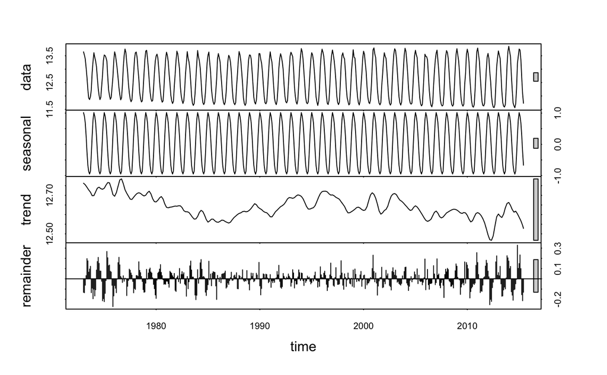

```r
decomp = stl(train, s.window="periodic")
plot(decomp)
```

The stl decomposition seems to capture well the seasonality “graphically”. We’ll see how well this translates into forecasts. Our first attempt will just forecast the time series by removing seasonality, and then using the last observation to which we add back the seasonality as the next forecast value.

```r
stlfk_naive = forecast(decomp, method="naive", h=12)
summary(stlfk_naive)
```

```
Forecast method: STL +  Random walk

Model Information:
$drift
[1] 0

$drift.se
[1] 0

$sd
[1] 0.09023216

$call
rwf(y = x, h = h, drift = FALSE, level = level)


Error measures:
                        ME       RMSE        MAE          MPE      MAPE      MASE        ACF1
Training set -0.0004587216 0.09014465 0.06759804 -0.006234602 0.5284953 0.8732574 -0.09577716

Forecasts:
         Point Forecast    Lo 80    Hi 80    Lo 95    Hi 95
Jul 2015       11.52510 11.40957 11.64062 11.34842 11.70178
Aug 2015       11.44640 11.33087 11.56192 11.26972 11.62308
Sep 2015       11.53739 11.42186 11.65291 11.36071 11.71407
Oct 2015       12.05578 11.94026 12.17131 11.87910 12.23246
Nov 2015       12.67021 12.55469 12.78574 12.49353 12.84690
Dec 2015       13.18247 13.06695 13.29800 13.00579 13.35915
Jan 2016       13.41230 13.29677 13.52782 13.23562 13.58898
Feb 2016       13.29855 13.18303 13.41408 13.12187 13.47523
Mar 2016       13.08706 12.97154 13.20259 12.91038 13.26374
Apr 2016       12.66947 12.55395 12.78500 12.49279 12.84615
May 2016       12.15371 12.03818 12.26923 11.97703 12.33039
Jun 2016       11.72784 11.61231 11.84336 11.55115 11.90452
```

```r
accuracy(stlfk_naive, test)
```

```
                        ME       RMSE        MAE          MPE      MAPE      MASE        ACF1 Theil's U
Training set -0.0004587216 0.09014465 0.06759804 -0.006234602 0.5284953 0.8732574 -0.09577716        NA
Test set      0.0984665485 0.13661429 0.10752662  0.769520343 0.8394485 1.3890700  0.29228001 0.3240292
```

Let’s try with exponential smoothing to forecast the seasonally-adjusted series.

```r
stlfk_ets = forecast(decomp, method="ets", h=12)
summary(stlfk_ets)
```

```
Forecast method: STL +  ETS(M,N,N)

Model Information:
ETS(M,N,N)

Call:
 ets(y = x, model = etsmodel, allow.multiplicative.trend = allow.multiplicative.trend)

  Smoothing parameters:
    alpha = 0.8899

  Initial states:
    l = 12.6302

  sigma:  0.0071

     AIC     AICc      BIC
724.4449 724.4923 737.1481

Error measures:
                        ME       RMSE        MAE         MPE     MAPE      MASE        ACF1
Training set -0.0005270008 0.08957449 0.06699331 -0.00705005 0.524313 0.8654452 0.006014702

Forecasts:
         Point Forecast    Lo 80    Hi 80    Lo 95    Hi 95
Jul 2015       11.51893 11.40642 11.63144 11.34687 11.69100
Aug 2015       11.44023 11.28963 11.59084 11.20990 11.67056
Sep 2015       11.53122 11.35037 11.71207 11.25464 11.80781
Oct 2015       12.04961 11.84290 12.25633 11.73347 12.36576
Nov 2015       12.66405 12.43436 12.89374 12.31277 13.01532
Dec 2015       13.17631 12.92574 13.42687 12.79310 13.55951
Jan 2016       13.40613 13.13630 13.67596 12.99346 13.81880
Feb 2016       13.29238 13.00458 13.58019 12.85222 13.73255
Mar 2016       13.08090 12.77616 13.38563 12.61485 13.54694
Apr 2016       12.66331 12.34254 12.98407 12.17274 13.15387
May 2016       12.14754 11.81151 12.48357 11.63363 12.66146
Jun 2016       11.72167 11.37103 12.07230 11.18542 12.25792
```

```r
accuracy(stlfk_ets, test)
```

```
                        ME       RMSE        MAE         MPE      MAPE      MASE        ACF1 Theil's U
Training set -0.0005270008 0.08957449 0.06699331 -0.00705005 0.5243130 0.8654452 0.006014702        NA
Test set      0.1046336198 0.14112405 0.11216904  0.81905384 0.8768599 1.4490426 0.292280013 0.3346012
```

It actually does worse than the naive technique. As a last attempt, we can also use arima on the seasonally-adjusted data.

```r
stlfk_arima = forecast(decomp, method="arima", h=12)
summary(stlfk_arima)
```

```
Forecast method: STL +  ARIMA(3,1,2)

Model Information:
Series: x
ARIMA(3,1,2)

Coefficients:
         ar1      ar2      ar3      ma1     ma2
      1.3257  -0.4219  -0.1728  -1.6815  0.7146
s.e.  0.0619   0.0805   0.0491   0.0466  0.0483

sigma^2 estimated as 0.006182:  log likelihood=573.58
AIC=-1135.15   AICc=-1134.99   BIC=-1109.76

Error measures:
                      ME       RMSE       MAE         MPE      MAPE      MASE        ACF1
Training set -0.00173105 0.07816114 0.0588041 -0.01744146 0.4599125 0.7596539 -0.02219796

Forecasts:
         Point Forecast    Lo 80    Hi 80    Lo 95    Hi 95
Jul 2015       11.60443 11.50366 11.70519 11.45032 11.75853
Aug 2015       11.61868 11.49882 11.73854 11.43537 11.80199
Sep 2015       11.78782 11.65912 11.91652 11.59099 11.98465
Oct 2015       12.35688 12.22653 12.48724 12.15752 12.55624
Nov 2015       12.98946 12.85910 13.11981 12.79010 13.18882
Dec 2015       13.49089 13.35981 13.62197 13.29042 13.69136
Jan 2016       13.68995 13.55758 13.82232 13.48751 13.89239
Feb 2016       13.53685 13.40361 13.67009 13.33308 13.74063
Mar 2016       13.28805 13.15464 13.42146 13.08402 13.49208
Apr 2016       12.84291 12.70944 12.97638 12.63878 13.04703
May 2016       12.31316 12.17894 12.44739 12.10788 12.51844
Jun 2016       11.88682 11.75087 12.02277 11.67890 12.09474
```

```r
accuracy(stlfk_arima, test)
```

```
                      ME       RMSE       MAE         MPE      MAPE      MASE        ACF1 Theil's U
Training set -0.00173105 0.07816114 0.0588041 -0.01744146 0.4599125 0.7596539 -0.02219796        NA
Test set     -0.12150070 0.14220379 0.1228988 -0.97753194 0.9877384 1.5876540 -0.15231347 0.3438054
```

R picked an ARIMA(3,1,2). The results aren’t as good as with the naive approach either. To conclude on this approach, it seems that the best model is to do a naive forecast on the seasonally-adjusted data.

We should note that what we are interested in is the RMSE on the test set for the values of the gas consumption, and not for their log.

```r
kable(data.frame("naive"=exp_rmse(stlfk_naive$mean, test),
           "ets"=exp_rmse(stlfk_ets$mean, test),
           "arima"=exp_rmse(stlfk_arima$mean, test), row.names = "RMSE"), align='c')
```

|  | naive | ets | arima |
| --- | --- | --- | --- |
| RMSE | 77722.56 | 79507.5 | 60795.39 |

According to this criterion, the model to pick is the ARIMA one.

## Time Series Decomposition with direct gas consumption

The approach is the same as above, but this time we fit the models to the data directly and not to the log of it. It is equivalent to doing an additive decomposition.

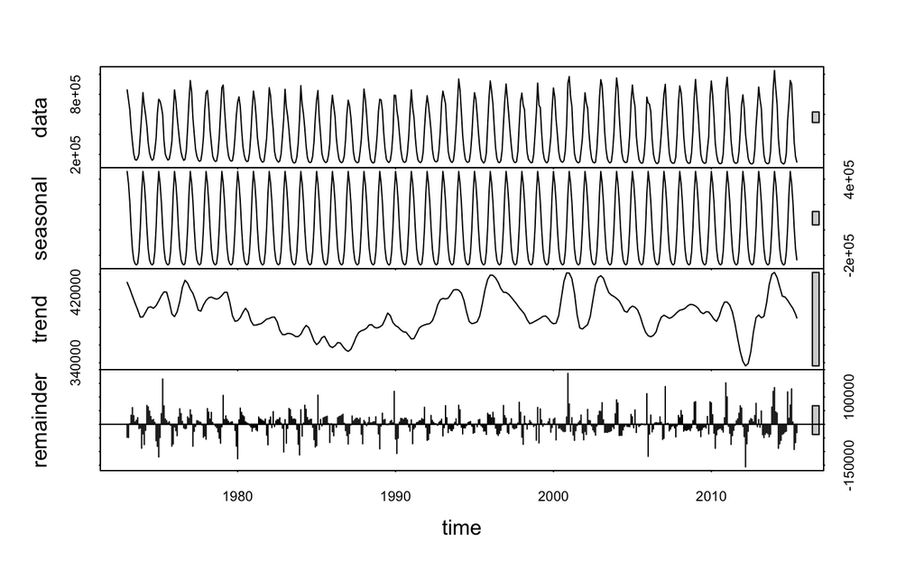

```r
ddecomp = stl(dtrain, s.window="periodic")
plot(ddecomp)
```

Just as in the previous case, graphically the decomposition seems interesting. The trend seems a bit harder to spot in this one. There seems to be extreme peaks which may be problematic for our forecasts.

Let’s fit the naive, exponential smoothing and arima models now.

```r
dstl_naive = forecast(ddecomp, method="naive", h=12)
dstl_ets = forecast(ddecomp, method="ets", h=12)
dstl_arima = forecast(ddecomp, method="arima", h=12)
summary(dstl_naive)
```

```
Forecast method: STL +  Random walk

Model Information:
$drift
[1] 0

$drift.se
[1] 0

$sd
[1] 48015.64

$call
rwf(y = x, h = h, drift = FALSE, level = level)


Error measures:
                    ME     RMSE      MAE        MPE     MAPE      MASE       ACF1
Training set -45.75346 47968.48 31623.02 -0.2747371 7.751035 0.8744243 -0.1915393

Forecasts:
         Point Forecast     Lo 80    Hi 80       Lo 95    Hi 95
Jul 2015       94270.84  32796.76 155744.9    254.3545 188287.3
Aug 2015       84031.36  22557.28 145505.4  -9985.1258 178047.8
Sep 2015       95367.62  33893.54 156841.7   1351.1316 189384.1
Oct 2015      184854.82 123380.74 246328.9  90838.3333 278871.3
Nov 2015      374232.89 312758.81 435707.0 280216.4028 468249.4
Dec 2015      646363.90 584889.82 707838.0 552347.4122 740380.4
Jan 2016      820611.49 759137.42 882085.6 726595.0074 914628.0
Feb 2016      728237.75 666763.68 789711.8 634221.2658 822254.2
Mar 2016      582575.01 521100.94 644049.1 488558.5297 676591.5
Apr 2016      372965.53 311491.45 434439.6 278949.0453 466982.0
May 2016      209496.61 148022.54 270970.7 115480.1311 303513.1
Jun 2016      123975.00  62500.93 185449.1  29958.5166 217991.5
```

```r
summary(dstl_ets)
```

```
Forecast method: STL +  ETS(A,N,N)

Model Information:
ETS(A,N,N)

Call:
 ets(y = x, model = etsmodel, allow.multiplicative.trend = allow.multiplicative.trend)

  Smoothing parameters:
    alpha = 0.6914

  Initial states:
    l = 419740.7679

  sigma:  46595.57

     AIC     AICc      BIC
14149.80 14149.84 14162.50

Error measures:
                    ME     RMSE      MAE        MPE     MAPE      MASE       ACF1
Training set -192.7531 46595.57 31620.76 -0.4278733 8.156581 0.8743619 0.05871077

Forecasts:
         Point Forecast      Lo 80    Hi 80       Lo 95    Hi 95
Jul 2015       86296.34  26581.714 146011.0   -5029.299 177622.0
Aug 2015       76056.86   3459.412 148654.3  -34971.356 187085.1
Sep 2015       87393.12   3876.996 170909.2  -40333.768 215120.0
Oct 2015      176880.32  83716.509 270044.1   34398.567 319362.1
Nov 2015      366258.39 264356.237 468160.5  210412.497 522104.3
Dec 2015      638389.40 528441.222 748337.6  470238.173 806540.6
Jan 2016      812636.99 695192.732 930081.3  633021.496 992252.5
Feb 2016      720263.25 595773.464 844753.0  529872.550 910654.0
Mar 2016      574600.52 443443.128 705757.9  374012.601 775188.4
Apr 2016      364991.03 227488.983 502493.1  154699.795 575282.3
May 2016      201522.12  57955.525 345088.7  -18044.038 421088.3
Jun 2016      116000.50 -33384.635 265385.6 -112464.350 344465.4
```

```r
summary(dstl_arima)
```

```
Forecast method: STL +  ARIMA(1,0,0) with non-zero mean

Model Information:
Series: x
ARIMA(1,0,0) with non-zero mean

Coefficients:
         ar1   intercept
      0.5363  395398.318
s.e.  0.0373    4003.951

sigma^2 estimated as 1.773e+09:  log likelihood=-6153.29
AIC=12312.57   AICc=12312.62   BIC=12325.28

Error measures:
                    ME     RMSE      MAE        MPE     MAPE      MASE       ACF1
Training set -19.92559 42023.99 27299.12 -0.7325736 6.236539 0.7548619 0.02936418

Forecasts:
         Point Forecast     Lo 80    Hi 80     Lo 95    Hi 95
Jul 2015       110802.1  56840.27 164763.9  28274.61 193329.6
Aug 2015       109428.1  48196.21 170660.0  15782.00 203074.2
Sep 2015       125518.8  62350.75 188686.9  28911.60 222126.0
Oct 2015       217555.8 153841.75 281269.8 120113.59 314997.9
Nov 2015       408301.2 344431.06 472171.4 310620.24 505982.2
Dec 2015       681165.6 617250.55 745080.6 583415.99 778915.1
Jan 2016       855806.4 791878.52 919734.3 758037.14 953575.7
Feb 2016       763643.6 699711.98 827575.2 665868.63 861418.5
Mar 2016       618094.0 554161.28 682026.6 520317.37 715870.5
Apr 2016       408545.1 344612.15 472478.1 310768.07 506322.2
May 2016       245108.7 181175.68 309041.8 147331.55 342885.9
Jun 2016       159604.6  95671.48 223537.7  61827.35 257381.8
```

```r
accuracy(dstl_naive, dtest)
```

```
                      ME     RMSE      MAE        MPE      MAPE      MASE        ACF1 Theil's U
Training set   -45.75346 47968.48 31623.02 -0.2747371  7.751035 0.8744243 -0.19153932        NA
Test set     -8647.06715 48462.13 35825.07  0.4779919 10.670010 0.9906173  0.07630088 0.2475476
```

```r
accuracy(dstl_arima, dtest)
```

```
                       ME     RMSE      MAE         MPE      MAPE      MASE       ACF1 Theil's U
Training set    -19.92559 42023.99 27299.12  -0.7325736  6.236539 0.7548619 0.02936418        NA
Test set     -40862.99755 64275.22 46467.43 -13.9318194 14.561932 1.2848947 0.12975328 0.2997268
```

```r
accuracy(dstl_ets, dtest)
```

```
                    ME     RMSE      MAE        MPE      MAPE      MASE       ACF1 Theil's U
Training set -192.7531 46595.57 31620.76 -0.4278733  8.156581 0.8743619 0.05871077        NA
Test set     -672.5696 47689.19 37092.65  4.3520340 12.707022 1.0256679 0.07630088 0.3058589
```

```r
kable(data.frame("naive"=direct_rmse(dstl_naive$mean, dtest),
           "ets"=direct_rmse(dstl_ets$mean, dtest),
           "arima"=direct_rmse(dstl_arima$mean, dtest), row.names = "RMSE"), align='c')
```

|  | naive | ets | arima |
| --- | --- | --- | --- |
| RMSE | 48462.13 | 47689.19 | 64275.22 |

This time an ARIMA(1, 0, 0) is picked. The best performing model is the exponential smoothing one (ets). This additive approach performs better than the multiplicative approach we outlined in the previous section.

```r
final_stl = forecast(stl(window(dgas, start = c(1973, 1), end = c(2016, 6)), s.window="periodic"), method="ets", h=12)
write.csv(final_stl$mean, "univariate_decomposition_predictions.csv")
```

We write our predictions to a file.

## Seasonal ARIMA

Let us now try a different approach and forecast the log gas consumption with Seasonal ARIMA Models.

### Auto Arima on the log data

```r
autofit = auto.arima(train, seasonal=TRUE)
print(autofit)
```

```
Series: train
ARIMA(2,0,0)(1,1,1)[12] with drift

Coefficients:
         ar1     ar2    sar1     sma1   drift
      0.4926  0.0477  0.0011  -0.7531  -3e-04
s.e.  0.0462  0.0448  0.0600   0.0426   2e-04

sigma^2 estimated as 0.005867:  log likelihood=570.36
AIC=-1128.71   AICc=-1128.54   BIC=-1103.45
```

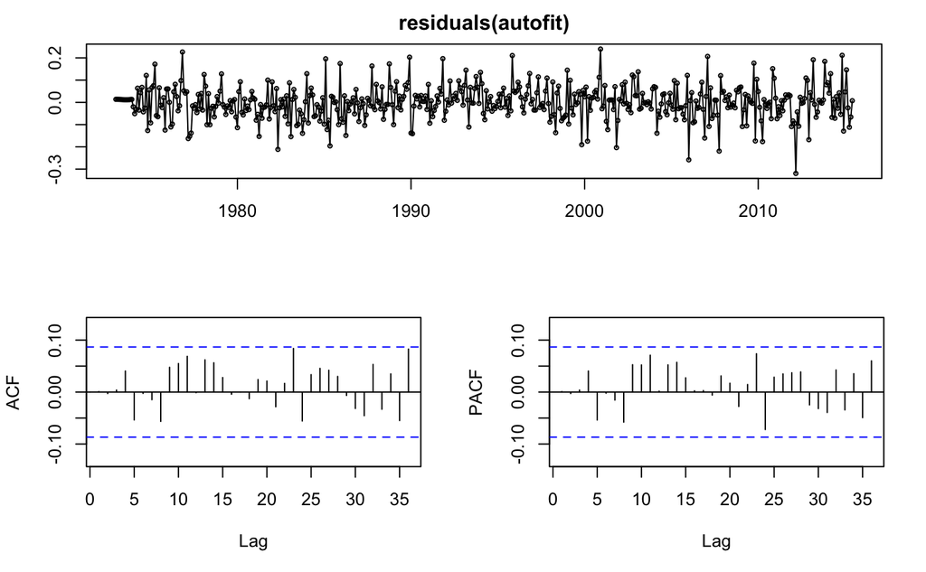

```r
tsdisplay(residuals(autofit))
```

```r
autofk = forecast(autofit,h=12)
accuracy(autofk,test)
```

```
                        ME       RMSE        MAE         MPE      MAPE      MASE         ACF1 Theil's U
Training set -1.829478e-05 0.07530712 0.05583933 -0.00504198 0.4352824 0.7213539 0.0009485353        NA
Test set     -8.278783e-02 0.12016739 0.08700562 -0.64410685 0.6787249 1.1239719 0.0958657683 0.2804928
```

The ACF and PACF of the residuals show no significant spikes.

### Custom Seasonal Arima on the log data

```r
custfit = Arima(train, order=c(4,0,1), seasonal=c(0,1,1))
print(custfit)
```

```
Series: train
ARIMA(4,0,1)(0,1,1)[12]

Coefficients:
          ar1     ar2     ar3     ar4     ma1     sma1
      -0.0545  0.3166  0.0228  0.0381  0.5493  -0.7441
s.e.   0.3757  0.1908  0.0499  0.0452  0.3738   0.0337

sigma^2 estimated as 0.005905:  log likelihood=569.4
AIC=-1124.81   AICc=-1124.58   BIC=-1095.33
```

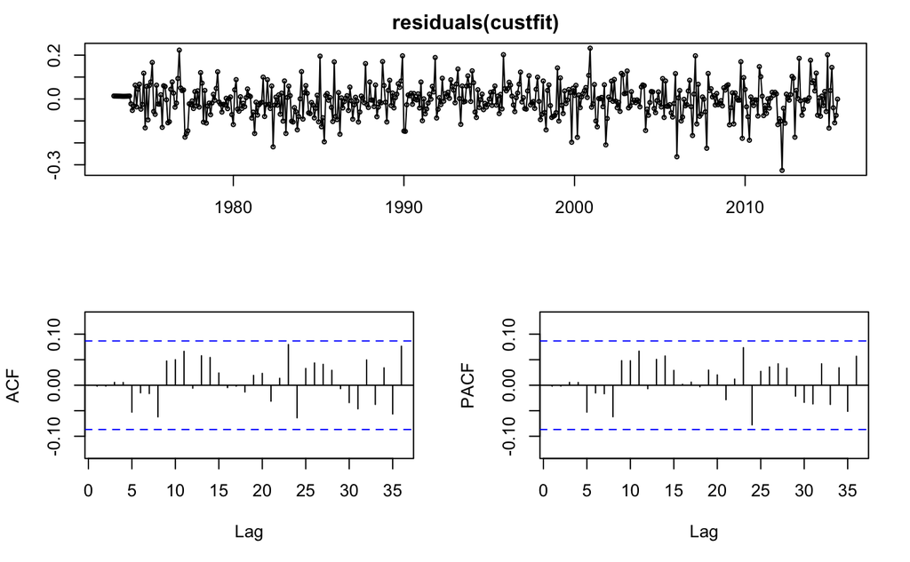

```r
tsdisplay(residuals(custfit))
```

```r
custfk = forecast(custfit,h=12)
accuracy(custfk,test)
```

```
                       ME       RMSE        MAE         MPE      MAPE      MASE         ACF1 Theil's U
Training set -0.005036636 0.07547694 0.05610723 -0.04471939 0.4377556 0.7248147 -0.001948896        NA
Test set     -0.093408622 0.12865998 0.09585320 -0.72825351 0.7483177 1.2382683  0.114421703 0.3006528
```

Again, we find no alarming spikes in the residuals. But this model is outperformed by the the one found automatically.

### Seasonal Arima on the actual data

```r
dautofit = auto.arima(dtrain, seasonal=TRUE)
print(dautofit)
```

```
Series: dtrain
ARIMA(3,0,3)(0,0,2)[12] with non-zero mean

Coefficients:
         ar1     ar2      ar3     ma1      ma2     ma3    sma1    sma2   intercept
      0.7523  0.5907  -0.8473  0.0727  -0.7353  0.0931  0.5205  0.2764  396001.316
s.e.  0.0534  0.0804   0.0453  0.0837   0.0376  0.0646  0.0491  0.0467    4104.313

sigma^2 estimated as 3.764e+09:  log likelihood=-6345.9
AIC=12711.8   AICc=12712.24   BIC=12754.14
```

```r
dautofk = forecast(dautofit,h=12)
accuracy(dautofk,dtest)
```

```
                      ME     RMSE      MAE        MPE     MAPE     MASE       ACF1 Theil's U
Training set    323.5301 60805.51 46602.48  -3.560537 15.66163 1.288629 0.01116995        NA
Test set     -47042.4200 89646.97 70956.37 -29.251244 32.24462 1.962051 0.35937203  1.273863
```

This time the RMSE is quite high. Comparing with the results on the log data gives the following RMSE:

```r
kable(data.frame("Direct"=accuracy(dautofk,dtest)[2, "RMSE"],
           "Logarithm"=exp_rmse(autofk$mean, test), row.names="RMSE"), align='c')
```

|  | Direct | Logarithm |
| --- | --- | --- |
| RMSE | 89646.97 | 67604.67 |

The seasonal ARIMA is not doing any good on the actual data, compared to the log data.

### Rolling Window Evaluation

To compare models more precisely, we would like to setup a rolling window evaluation. Let us find the optimal size of that window using the Auto ARIMA we just fitted, by comparing the performances on RMSE of models with different training test time span.

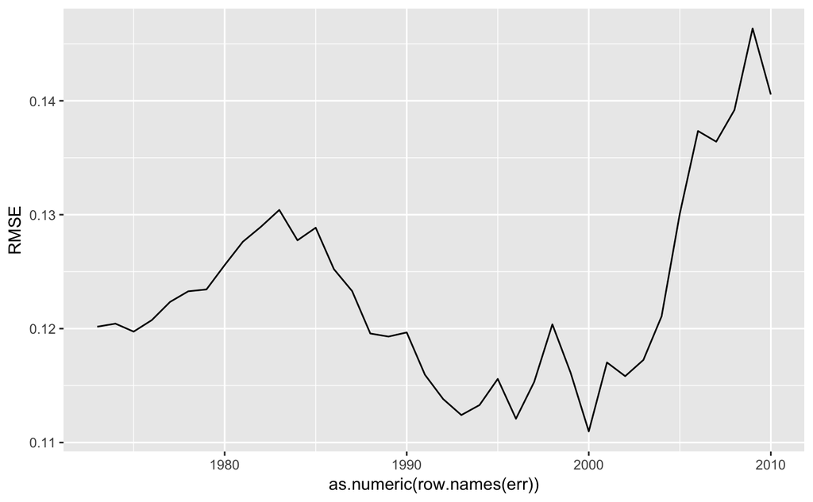

```r
err = data.frame("RMSE" = rep(0, 2010-1973+1), row.names = seq(1973, 2010))
for (y in 1973:2010){
    model = Arima(window(train, start=c(y,1)), order=c(2,0,0), seasonal=c(1,1,1), include.drift = TRUE)
    rmse = accuracy(forecast(model, h=12),test)[2,"RMSE"]
    err[as.character(y),] = rmse
}
ggplot(err)+geom_line(aes(x=as.numeric(row.names(err)), y=RMSE))
```

Let us take a closer look at the year 2000.

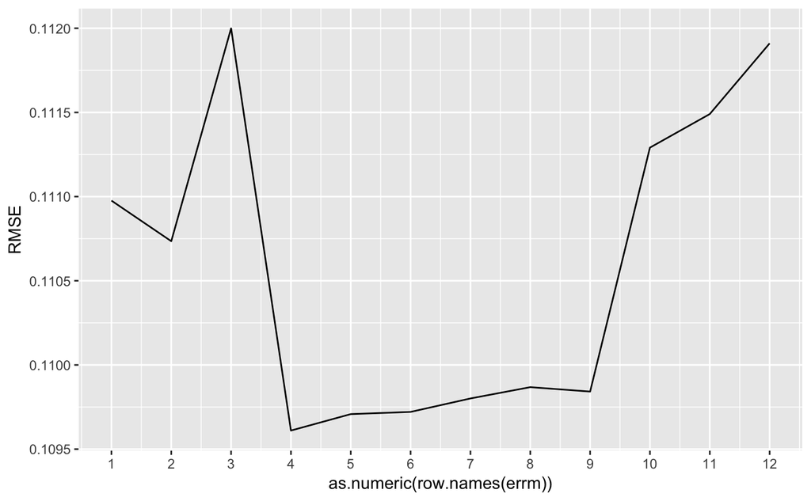

```r
errm = data.frame("RMSE" = rep(0, 12), row.names = seq(1, 12))
for (m in 1:12){
    model = Arima(window(train, start=c(2000,m)), order=c(2,0,0), seasonal=c(1,1,1), include.drift = TRUE)
    rmse = accuracy(forecast(model, h=12),test)[2,"RMSE"]
    errm[as.character(m),] = rmse
}
ggplot(errm)+geom_line(aes(x=as.numeric(row.names(errm)), y=RMSE))+scale_x_continuous(breaks=seq(1,12))
```

We will thus use a rolling window of 15 years, and define the R function below:

```r
roll = function(p,d,q,P,D,Q, drift){
    RMSE = rep(0,28)
    RMSLE = rep(0,28)
    for (y in 1973:2000){
        tr = window(lgas, start=c(y,7), end=c(y+15,6))
        te = window(lgas, start=c(y+15,7), end=c(y+16,6))
        model = Arima(tr, order=c(p,d,q), seasonal=c(P,D,Q), include.drift = drift)
        RMSLE[y+1-1973] = accuracy(forecast(model, h=12),te)[2,"RMSE"]
        RMSE[y+1-1973] = exp_rmse(forecast(model, h=12)$mean, te)
    }
    return(rbind(RMSE, RMSLE))
}
```

We can now, evaluate models predictions on different years. We try below different seasonal arima, reducing the number of lags little by little.

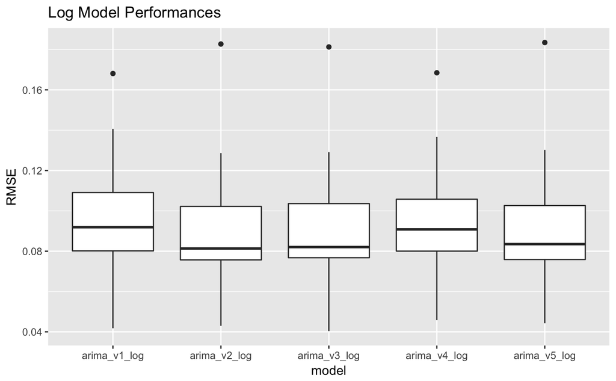

```r
eval = data.frame('run'=seq(1:28))
eval[c('arima_v1_dir', 'arima_v1_log')] = t(roll(2,0,0,1,1,1,TRUE))
eval[c('arima_v2_dir', 'arima_v2_log')] = t(roll(4,0,0,0,1,1,FALSE))
eval[c('arima_v3_dir', 'arima_v3_log')] = t(roll(2,0,0,1,1,1,FALSE))
eval[c('arima_v4_dir', 'arima_v4_log')] = t(roll(1,0,0,0,1,1,TRUE))
eval[c('arima_v5_dir', 'arima_v5_log')] = t(roll(1,0,0,0,1,1,FALSE))
ggplot(stack(eval[,(names(eval) != "run")&grepl('log',names(eval))]))+geom_boxplot(aes(x=ind, y=values))+
    labs(x='model', title="Log Model Performances", y="RMSE")
```

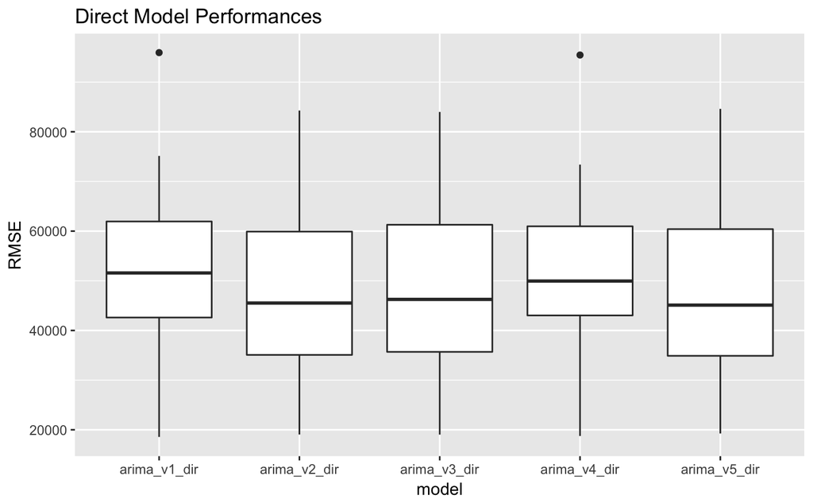

```r
ggplot(stack(eval[,(names(eval) != "run")&grepl('dir',names(eval))]))+geom_boxplot(aes(x=ind, y=values))+
    labs(x='model', title="Direct Model Performances", y="RMSE")
```

[figure not shown]

In the end we have the following predictions:

```r
exp(finalFkst$mean)
```

[output not shown]

```
          Jan      Feb      Mar      Apr      May      Jun      Jul      Aug      Sep      Oct      Nov
2016                                                       110153.4 105928.3 115945.2 214663.3 455528.5
2017 910957.0 777040.5 568530.5 337620.7 193516.8 127805.8
          Dec
2016 699763.5
2017
```